```python
import numpy as np
import matplotlib.pyplot as plt
from transformers import AutoTokenizer, AutoModelForCausalLM, BitsAndBytesConfig, pipeline
import torch

from tqdm import tqdm
```

[output not shown]

```python
model_name = "meta-llama/Meta-Llama-3-8B"
bnb_config = BitsAndBytesConfig(
    load_in_4bit=True,
    bnb_4bit_compute_dtype="bfloat16",
    bnb_4bit_quant_type="nf4",
    bnb_4bit_use_double_quant=True,
)
tokenizer = AutoTokenizer.from_pretrained(model_name)
model = AutoModelForCausalLM.from_pretrained(
    model_name,
    quantization_config=bnb_config,
    device_map="auto"
)
```

# 1. Tokenisation

```python
prompt = "Le chat s'assoit"
inputs = tokenizer(prompt, return_tensors='pt').to(model.device)
print("jetons du prompt: ", inputs['input_ids'])
```

```
jetons du prompt:  tensor([[128000,   2356,   6369,    274,      6,  29963,    275]],
       device='cuda:0')
```

# 2. La distribution de probabilité du mot suivant

```python
with torch.no_grad():
    outputs = model(**inputs)

logits = outputs.logits  # shape: [batch_size, seq_len, vocab_size]
print(logits.shape)
```

```
torch.Size([1, 7, 128256])
```

128256 est la taille du vocabulaire du **Llama 3**.

**Llama 3** prédits le mot suivant (dans la phrase de sortie) pour tous les mots dans la pharse d'entrée. Comme la phrase d'entrée est convertie à 7 jetons, la sortie générée par **Llama 3** est une matrice de 7 lignes.

```python
k = 10
logits_mot_suivant = logits[0, -1, :]
topk_logits, topk_indices = torch.topk(logits_mot_suivant, k=k,)
print("top-k logits: ", topk_logits)


bottomk_logits, bottomk_indices = torch.topk(-logits_mot_suivant, k=k,)
print("bottomk_logits : ", -bottomk_logits)

# Ces valeurs ne réprsentent pas la probabilité car ils sont à l'extérieur l'intervalle [0, 1[
```

```
top-k logits:  tensor([14.9766, 13.4922, 13.4531, 13.3359, 13.1641, 13.0625, 12.8047, 12.4375,
        12.3203, 12.2891], device='cuda:0', dtype=torch.float16)
bottomk_logits :  tensor([-13.1719, -12.5156, -11.7812, -11.6875, -11.5156, -11.4375, -11.3828,
        -11.3672, -11.3516, -11.2812], device='cuda:0', dtype=torch.float16)
```

## Transformer la sortie de LLM en distribution de probabilité du mot suivant

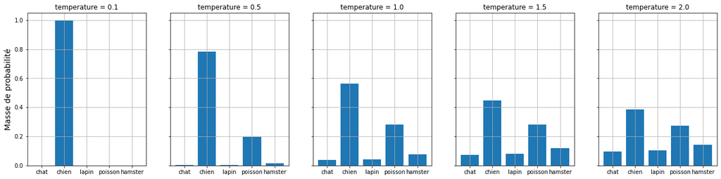

```python
categories = ['chat', 'chien', 'lapin', 'poisson', 'hamster']
logits_ = np.array([0.24, 2.99, 0.4, 2.3, 0.99])
temperatures = [0.1, 0.5, 1.0, 1.5, 2.0]

fig, ax = plt.subplots(1, len(temperatures), figsize=(22, 5), sharey=True)
for i, t in enumerate(temperatures):
    prob_ = np.exp(logits_ / t)
    prob_ = prob_ / np.sum(prob_)
    ax[i].bar(categories, prob_)
    ax[i].grid()
    if i == 0:
        ax[i].set_ylabel("Masse de probabilité", fontsize=14)
    ax[i].set_title(f" temperature = {t} ")

# plus la température est élevée, plus la distribution est uniforme.
```

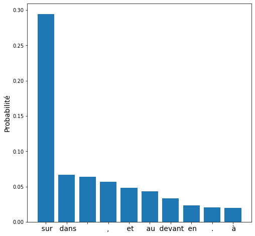

```python
prob_mot_suivant = torch.nn.functional.softmax(logits_mot_suivant)
topk_prob = prob_mot_suivant[topk_indices].cpu().tolist()
topk_tokens = [tokenizer.decode([tid]) for tid in topk_indices.cpu().tolist()]

fig, ax = plt.subplots(figsize=(8, 8))
ax.bar(topk_tokens, topk_prob, )
ax.set_ylabel("Probabilité", fontsize=14)
_ = plt.xticks(fontsize=14)
```

# 3. L'échantillonnage glouton

Idée : **Sélectionner le jeton ayant la plus forte probabilité**

```python
longeur_sortie = 50
jetons_sortie = list()

generated = inputs['input_ids']
for i in tqdm(range(longeur_sortie)):
    with torch.no_grad():
        outputs = model(input_ids=generated)

    logits = outputs.logits  # (batch_size, seq_len, vocab_size)
    jeton_suivant_logits = logits[:, -1, :]  # (batch_size, vocab_size)

    # échantillonnage glouton
    jeton_suivant = torch.argmax(jeton_suivant_logits, dim=1, keepdim=True)  # (batch_size, 1)
    generated = torch.cat([generated, jeton_suivant], dim=1)
```

```python
phrase_sortie = ""
for tid in generated[0].cpu().tolist():
    phrase_sortie += tokenizer.decode([tid])

print(phrase_sortie)
```

```
<|begin_of_text|>Le chat s'assoit sur le fauteuil
The cat sits on the chair
The cat sits on the chair
The cat sits on the chair
The cat sits on the chair
The cat sits on the chair
The cat sits on the chair
The cat
```

## Que pensez-vous de cette réponse ?

```python
# déterministe
# très rapidment de se répéter
```

# 4. Recherche en faisceau

```python
def decode(list_jetons):
    assert isinstance(list_jetons, list), f"{type(list_jetons)}"
    phrase_sortie = ""
    for tid in list_jetons:
        phrase_sortie += tokenizer.decode([tid])
    return phrase_sortie
```

```python
longeur_sortie = 10  # à changer à 5
nb_faisceaux = 2
generated = inputs['input_ids']  # (nb_faisceau, longeur_entree) ou (1, longeur_entree) à la 1e itération
faisceaux_total_prob = None
histoire_faisceaux_total_prob = np.zeros((nb_faisceaux, longeur_sortie))

for idx_jeton_genere in range(longeur_sortie):
    print("=========================================\n")
    print(f"itération {idx_jeton_genere}")
    print("Les faiceaux d'entrée :")
    for idx_phrase_entre in range(generated.shape[0]):
        print(decode(generated[idx_phrase_entre].cpu().tolist()))
    print("------------\n")

    with torch.no_grad():
        outputs = model(input_ids=generated)  # generated: (nb_faisceaux, longeur_entree à cette itération)

    logits = outputs.logits  # (nb_faisceau, seq_len, vocab_size)
    jeton_suivant_prob = torch.nn.functional.softmax(logits[:, -1, :], dim=1)  # (nb_faisceaux, vocab_size)

    if faisceaux_total_prob is None:
        # 1e itération
        # garde "nb_faiceau" jetons
        top_prob, top_jetons = torch.topk(jeton_suivant_prob.reshape(-1), k=nb_faisceaux)
        # top_logits: (nb_faisceaux,)
        # top_jetons: (nb_faisceaux,)

        faisceaux_total_prob = top_prob.reshape(-1, 1)  # (nb_faisceaux, 1)

        # ajoute top_jetons dans la phrase de sortie
        # car il y a "nb_faisceaux" jetons à conserver à la 1e itération, il faut multiplier la phrase de sorties "nb_faisceaux" fois
        # pour représenter "nb_faisceaux" options de la phrase de sortie
        generated = torch.cat([generated.repeat(nb_faisceaux, 1), top_jetons.reshape(-1, 1)], dim=1)  # (nb_faisceaux, longeur_entree + 1)

    else:
        # à partir de la 2e itération
        # montrer topk de chaque faisceau d'entrée
        for idx_phrase_entre in range(generated.shape[0]):
            print("===")
            _prob_entree = float(faisceaux_total_prob[idx_phrase_entre])
            print("Phrase d'entrée: ", decode(generated[idx_phrase_entre].cpu().tolist()), f"\t prob: {_prob_entree}")
            print("Top jetons suivant \t\t Prob jeton \t\t Prob phrase sorite")
            _top_prob, _top_jetons = torch.topk(jeton_suivant_prob[idx_phrase_entre], k=5)

            _top_jetons = _top_jetons.cpu().tolist()
            for _idx_jeton in range(_top_prob.shape[0]):
                _prob_jeton = np.round(float(_top_prob[_idx_jeton]), decimals=4)
                _prob_phrase_et_jeton = np.round(_prob_jeton * _prob_entree, decimals=4)
                print(f"{tokenizer.decode([_top_jetons[_idx_jeton]])} \t\t\t\t {_prob_jeton} \t\t\t\t {_prob_phrase_et_jeton}")

        """
        mise à jour les faiceaux et leur total logit
        """
        jeton_suivant_prob = jeton_suivant_prob *  faisceaux_total_prob  # (nb_faisceaux, vocab_size)
        top_prob, top_jetons = torch.topk(jeton_suivant_prob.reshape(-1), k=nb_faisceaux)  # top_logits : (nb_faisceaux,)
        # convertir les indices aplati en index 2D pour défaire reshape(-1) appliqué au jeton_suivant_logits
        vocab_size = jeton_suivant_logits.shape[-1]
        ind_top_faiceaux = top_jetons // vocab_size  # (nb_faisceaux,)
        top_jetons = top_jetons % vocab_size  # (nb_faisceaux,)

        # faiceaux sélectionés
        generated = generated[ind_top_faiceaux]  # (nb_faisceaux, longeur_entree)
        # ajoute top_jetons aux faiceaux sélectionés
        generated = torch.cat([generated, top_jetons.reshape(-1, 1)], dim=1)

        faisceaux_total_prob = top_prob.reshape(nb_faisceaux, -1)  # (nb_faisceaux, 1)

    print("Les faiceaux d'sortie :")
    print("Phrase \t Prob")
    for idx_phrase_sorite in range(generated.shape[0]):
        print(f"{decode(generated[idx_phrase_sorite].cpu().tolist())} \t {float(faisceaux_total_prob[idx_phrase_sorite])}")

    histoire_faisceaux_total_prob[:, idx_jeton_genere] += faisceaux_total_prob.reshape(-1).cpu().numpy()
```

```
=========================================

itération 0
Les faiceaux d'entrée :
<|begin_of_text|>Le chat s'assoit
------------

Les faiceaux d'sortie :
Phrase 	 Prob
<|begin_of_text|>Le chat s'assoit sur 	 0.294677734375
<|begin_of_text|>Le chat s'assoit dans 	 0.0667724609375
=========================================

itération 1
Les faiceaux d'entrée :
<|begin_of_text|>Le chat s'assoit sur
<|begin_of_text|>Le chat s'assoit dans
------------

===
Phrase d'entrée:  <|begin_of_text|>Le chat s'assoit sur 	 prob: 0.294677734375
Top jetons suivant 		 Prob jeton 		 Prob phrase sorite
 le 				 0.3062 				 0.0902
 une 				 0.16 				 0.0471
 la 				 0.1576 				 0.0464
 un 				 0.1564 				 0.0461
 l 				 0.0421 				 0.0124
===
Phrase d'entrée:  <|begin_of_text|>Le chat s'assoit dans 	 prob: 0.0667724609375
Top jetons suivant 		 Prob jeton 		 Prob phrase sorite
 le 				 0.3284 				 0.0219
 la 				 0.1814 				 0.0121
 un 				 0.1504 				 0.01
 l 				 0.1144 				 0.0076
 une 				 0.0694 				 0.0046
Les faiceaux d'sortie :
Phrase 	 Prob
<|begin_of_text|>Le chat s'assoit sur le 	 0.0902099609375
<|begin_of_text|>Le chat s'assoit sur une 	 0.047149658203125
=========================================
```

[output cut: 238 more lines]

```
===
Phrase d'entrée:  <|begin_of_text|>Le chat s'assoit sur le fauteuil
The cat sits 	 prob: 4.2498111724853516e-05
Top jetons suivant 		 Prob jeton 		 Prob phrase sorite
 on 				 0.874 				 0.0
 in 				 0.0788 				 0.0
 down 				 0.0299 				 0.0
 upon 				 0.0016 				 0.0
 the 				 0.0012 				 0.0
Les faiceaux d'sortie :
Phrase 	 Prob
<|begin_of_text|>Le chat s'assoit sur le fauteuil
Le chat s' 	 9.28044319152832e-05
<|begin_of_text|>Le chat s'assoit sur le fauteuil
The cat sits on 	 3.713369369506836e-05
```

## Remarque :

1. Le faisceau "Le chat s'assoit dans" disparaît dans la 2e itération
2. La probabilité cumulative de la phrase tend rapidement vers 0.

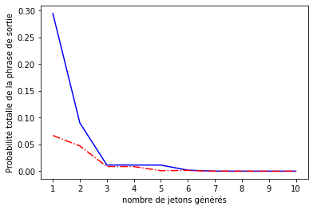

```python
fig, ax = plt.subplots()
steps = np.arange(longeur_sortie)
ax.plot(steps, histoire_faisceaux_total_prob[0], 'b-')
ax.plot(steps, histoire_faisceaux_total_prob[1], 'r-.')
ax.set_xticks(steps)
ax.set_xticklabels(steps + 1)
ax.set_xlabel("nombre de jetons générés")
ax.set_ylabel("Probabilité totalle de la phrase de sortie")
```

# 5. Echantillonage

## 5.0 Comment échantillonner une distribution

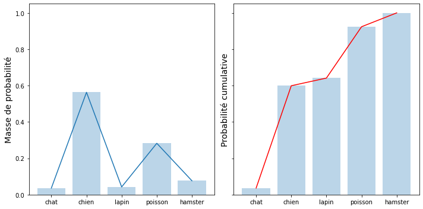

```python
categories = ['chat', 'chien', 'lapin', 'poisson', 'hamster']
logits = np.array([0.24, 2.99, 0.4, 2.3, 0.99])

temperatures = 1.0
prob = np.exp(logits / temperatures)
prob /= prob.sum()

prob_cumulative = np.cumsum(prob)

fig, ax = plt.subplots(1, 2, figsize=(10, 5), sharey=True)
ax[0].bar(categories, prob, alpha=0.3)
ax[0].plot(np.arange(len(categories)), prob)
ax[0].set_ylabel("Masse de probabilité", fontsize=14)

ax[1].bar(categories, prob_cumulative, alpha=0.3)
ax[1].plot(np.arange(len(categories)), prob_cumulative, 'r-')
ax[1].set_ylabel("Probabilité cumulative", fontsize=14)

fig.tight_layout()
```

```python
def recherche_dichotonomique(tab, ele):
    # return idx of the ele that is less or equal to ele
    begin = 0
    fin = len(tab) - 1
    found = False
    mid = -1
    while not found and begin <= fin:
        mid = (begin + fin) // 2
        if tab[mid] == ele:
            found = True
        elif tab[mid] < ele:
            begin = mid + 1
        else:
            fin = mid - 1  # fin peut arriver à -1

    if found:
        return mid
    else:
        # return ele that is less than ele
        # print(f"tab[begin]: {tab[begin]} | {ele}")
        # print(f"tab[fin]: {tab[fin]} | {ele}")
        # print("===")
        return begin


def sampling_categories(prob_cumulative) -> int:
    u = np.random.rand()
    return recherche_dichotonomique(prob_cumulative, u)
```

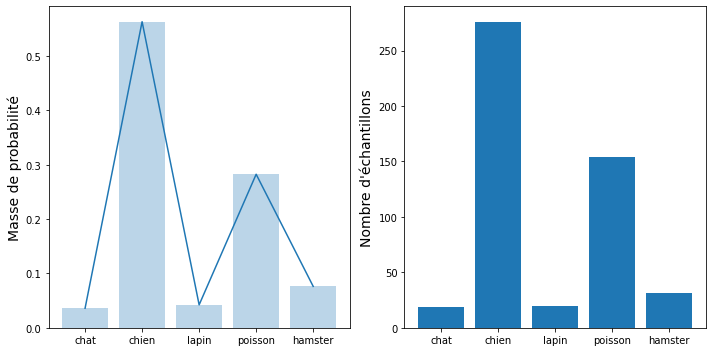

```python
num_samples_total = 500
num_samples_par_category = np.zeros(len(categories))

for i in range(num_samples_total):
    chosen_idx = sampling_categories(prob_cumulative)
    num_samples_par_category[chosen_idx] += 1

fig, ax = plt.subplots(1, 2, figsize=(10, 5))
ax[0].bar(categories, prob, alpha=0.3)
ax[0].plot(np.arange(len(categories)), prob)
ax[0].set_ylabel("Masse de probabilité", fontsize=14)

ax[1].bar(categories, num_samples_par_category)
ax[1].set_ylabel("Nombre d'échantillons", fontsize=14)

fig.tight_layout()
```

## 5.1 échantillonnage simple de la distribution des catégories

```python
longeur_sortie = 25
jetons_sortie = list()
generated = inputs['input_ids']  # (1, nb_jeton_entree)
vocab_size = None
all_ids = None

for i in tqdm(range(longeur_sortie)):
    with torch.no_grad():
        outputs = model(input_ids=generated)

    logits = outputs.logits  # (batch_size, seq_len, vocab_size)
    jeton_suivant_logits = logits[:, -1, :]  # (batch_size, vocab_size)

    if vocab_size is None:
        vocab_size = jeton_suivant_logits.shape[-1]
        all_ids = np.arange(vocab_size)

    # # échantillonnage glouton
    # jeton_suivant = torch.argmax(jeton_suivant_logits, dim=1, keepdim=True)  # (batch_size, 1)

    # échantillonnage
    jeton_suivant_prob = torch.nn.functional.softmax(jeton_suivant_logits, dim=1)  # (batch_size, vocab_size)
    jeton_suivant_prob_cumulative = torch.cumsum(jeton_suivant_prob, dim=1)  # (batch_size, vocab_size)

    jeton_suivant = sampling_categories(jeton_suivant_prob_cumulative[0].cpu())
    jeton_suivant = torch.from_numpy(np.array([jeton_suivant])).to(generated.device).reshape(1, 1)
    generated = torch.cat([generated, jeton_suivant], dim=1)
```

```python
phrase_sortie2 = ""
for tid in generated[0].cpu().tolist():
    phrase_sortie2 += tokenizer.decode([tid])

print(phrase_sortie2)
```

```
<|begin_of_text|>Le chat s'assoit devant, en face de moi, sans bouger, inexpressif, et les Please fair|honest|kindlyives
```

```python
phrase_sortie = ""
for tid in generated[0].cpu().tolist():
    phrase_sortie += tokenizer.decode([tid])

print(phrase_sortie)
```

[output not shown]

## 5.2 Top-k sampling

```python
longeur_sortie = 25
keep_topk = 10
generated = inputs['input_ids']  # (1, nb_jeton_entree)
vocab_size = None
all_ids = None

for i in tqdm(range(longeur_sortie)):
    with torch.no_grad():
        outputs = model(input_ids=generated)

    logits = outputs.logits  # (batch_size, seq_len, vocab_size)
    jeton_suivant_logits = logits[:, -1, :]  # (batch_size, vocab_size)

    if vocab_size is None:
        vocab_size = jeton_suivant_logits.shape[-1]
        all_ids = np.arange(vocab_size)

    topk_logits, topk_indices = torch.topk(jeton_suivant_logits[0], k=keep_topk)

    # échantillonnage
    jeton_suivant_prob = torch.nn.functional.softmax(topk_logits)  # (keep_topk,)
    jeton_suivant_prob_cumulative = torch.cumsum(jeton_suivant_prob, dim=0)  # (keep_topk,)

    jeton_suivant = sampling_categories(jeton_suivant_prob_cumulative.cpu())
    jeton_suivant = topk_indices[jeton_suivant].reshape(1, 1)
    generated = torch.cat([generated, jeton_suivant], dim=1)
```

```python
phrase_sortie_topk_1 = ""
for tid in generated[0].cpu().tolist():
    phrase_sortie_topk_1 += tokenizer.decode([tid])

print(phrase_sortie_topk_1)
```

```
<|begin_of_text|>Le chat s'assoit et sourit, puis s'assouplit, puis va dans une autre pièce et fait la même chose, etc
```

```python
phrase_sortie_topk_0 = ""
for tid in generated[0].cpu().tolist():
    phrase_sortie_topk_0 += tokenizer.decode([tid])

print(phrase_sortie_topk_0)
```

[output not shown]

### Résultats les plus intéressants

<|begin_of_text|>Le chat s'assoit et regarde les rayons du soleil se refléter sur la mer de l'océan Atlantique. La plage est un des lieux préférés des habitants de la ville de Saint-Malo, située

## 5.3 Top-p sampling

```python
longeur_sortie = 25
keep_topk = 10
val_top_p = 0.95
generated = inputs['input_ids']  # (1, nb_jeton_entree)
vocab_size = None
all_ids = None

for i in tqdm(range(longeur_sortie)):
    with torch.no_grad():
        outputs = model(input_ids=generated)

    logits = outputs.logits  # (batch_size, seq_len, vocab_size)
    jeton_suivant_logits = logits[:, -1, :]  # (batch_size, vocab_size)

    if vocab_size is None:
        vocab_size = jeton_suivant_logits.shape[-1]
        all_ids = np.arange(vocab_size)

    # échantillonnage
    jeton_suivant_prob = torch.nn.functional.softmax(jeton_suivant_logits[0])  # (vocab_size,)
    sorted_indices = torch.argsort(jeton_suivant_prob,  descending=True)

    somme_prob = 0
    idx = 0
    top_indices = list()
    top_prob = list()
    while somme_prob < val_top_p:
        chosen_idx = sorted_indices[idx]
        somme_prob += float(jeton_suivant_prob[chosen_idx])

        top_indices.append(int(chosen_idx))
        top_prob.append(float(jeton_suivant_prob[chosen_idx]))
        # ---
        idx += 1

    top_prob = np.array(top_prob) / val_top_p
    top_prob_cumulative = np.cumsum(top_prob)

    sampled_index = sampling_categories(top_prob_cumulative)
    jeton_suivant = torch.from_numpy(np.array([top_indices[sampled_index]])).to(generated.device).reshape(1, 1)
    generated = torch.cat([generated, jeton_suivant], dim=1)
```

```python
phrase_sortie_topp_1 = ""
for tid in generated[0].cpu().tolist():
    phrase_sortie_topp_1 += tokenizer.decode([tid])

print(phrase_sortie_topp_1)
```

```
<|begin_of_text|>Le chat s'assoit comme une fée. An icon used to represent a menu that can be toggled by interacting with this icon. An icon
```

```python
phrase_sortie_topp_0 = ""
for tid in generated[0].cpu().tolist():
    phrase_sortie_topp_0 += tokenizer.decode([tid])

print(phrase_sortie_topp_0)
```

[output not shown]

## Comment les LLM commerciaux générent-ils le mot suivant ?

- Gemini : https://ai.google.dev/gemini-api/docs/prompting-strategies?hl=fr#:~:text=Note%3A%20When%20using%20Gemini%203,complex%20mathematical%20or%20reasoning%20tasks.
- ChatGPT : https://platform.openai.com/docs/api-reference/responses/get
  - recherche les mots clés : temperature, top_logprobs, top_p
- Claude : https://platform.claude.com/docs/en/api/completions/create
  - "Use temperature closer to 0.0 for analytical / multiple choice, and closer to 1.0 for creative and generative tasks."

# 6. Comportements des LLM après l’entraînement

```python
pipe = pipeline(
    "text-generation",
    model=model,
    tokenizer=tokenizer,
    max_new_tokens=64,
)
```

```
Device set to use cuda:0
```

## 6.1 Complétion de texte

```python
prompt = "What is 2+2?"
out = pipe(prompt)[0]["generated_text"]
print(out)
```

```
Setting `pad_token_id` to `eos_token_id`:128001 for open-end generation.
```

```
What is 2+2? * This question is for testing whether or not you are a human sender. Enter the answer into the box below, then click continue to confirm that you are not a sender.
```

### résultats les plus intéressants

What is 2+2? If you said 4, you're wrong. The correct answer is 5. Here's a more difficult question. What plus what equals 100? If you said 50 + 50, you're wrong. The correct answer is 1 + 99. What is 2+2? If you said

## 6.2 Mémoriser de textes de son base d'entraînement

Texte extrait de Moby Dick :

Call me Ishmael. Some years ago--never mind how long precisely--having little or no money in my purse, and nothing particular to interest me on shore, I thought I would sail about a little and see the watery part of the world.

```python
text_wiki = "Call me Ishmael. Some years ago - never mind how long precisely -"  # (Moby Dicks)
out = pipe(text_wiki)[0]["generated_text"]
print(out)
```

```
Setting `pad_token_id` to `eos_token_id`:128001 for open-end generation.
```

```
Call me Ishmael. Some years ago - never mind how long precisely - having little or no money in my purse, and nothing particular to interest me on shore, I thought I would sail about a little and see the watery part of the world. It is a way I have of driving off the spleen and regulating the circula…
```

## 6.3 Connaissances limitées

```python
prompt = "Quel club a remporté la Ligue des champions de l'UEFA en 2025 ?"
out = pipe(prompt)[0]["generated_text"]
print(out)
```

```
Setting `pad_token_id` to `eos_token_id`:128001 for open-end generation.
```

```
Quel club a remporté la Ligue des champions de l'UEFA en 2025 ? Qui est le meilleur joueur du monde en 2025? Quel joueur a remporté le Ballon d'Or en 2025? Quel club a remporté la Ligue des champions de l'UEFA en 2024? Qui est le meilleur joueur du monde en 2024?
```

## Donner un coup de main : K-shot prompting

```python
prompt = "cheese =>"
out = pipe(prompt)[0]["generated_text"]
print(out)
```

```
Setting `pad_token_id` to `eos_token_id`:128001 for open-end generation.
```

```
cheese => [cheese] | cheese => [cheese] | cheese => [cheese] | cheese => [cheese] | cheese => [cheese] | cheese => [cheese] | cheese => [cheese] | cheese => [cheese] | cheese => [cheese] | cheese => [
```

#### Donner le contexte

```python
prompt = "Task: translate English to French. cheese =>"
out = pipe(prompt)[0]["generated_text"]
print(out)
```

```
Setting `pad_token_id` to `eos_token_id`:128001 for open-end generation.
```

```
Task: translate English to French. cheese => fromage, cheeseburger => hamburger, cheese platter => assiette de fromage, cheese board => plat de fromage. How to use cheese in a sentence. Cheese definition, a food made from the curd of milk by coagulation, pressing, and aging. Definition of cheese in …
```

#### Donnes les exemples

```python
prompt = "Task: Arithmetic. 2+2="
out = pipe(prompt)[0]["generated_text"]
print(out)
```

```
Setting `pad_token_id` to `eos_token_id`:128001 for open-end generation.
```

```
Task: Arithmetic. 2+2=4. 3*3=9. 6/2=3. 7-1=6.
Task: Arithmetic. 2+2=4. 3*3=9. 6/2=3. 7-1=6.
Task: Arithmetic. 2+2=
```

```python
prompt = "Task: Arithmetic. Examples:\nQuestion 2+2=?\nAnswer:4.\nQuestion 1+2=?\nAnswer:"
out = pipe(prompt)[0]["generated_text"]
print(out)
```

```
Setting `pad_token_id` to `eos_token_id`:128001 for open-end generation.
```

```
Task: Arithmetic. Examples:
Question 2+2=?
Answer:4.
Question 1+2=?
Answer:3.
Question 4-2=?
Answer:2.
Question 5*2=?
Answer:10.
Question 5/2=?
Answer:2.5.
Question 1/2=?
Answer:0.5.
Question 4/2=?
Answer:2.
```